# R Project

Alena Spiridonova

27 03 2021

Используемый датасет: пакет данных *heights* из библиотеки *modelr*.

**Format**

**income**  
Yearly income. The top two percent of values were averaged and that average was used to replace all values in the top range.*

**height**  
Height, in inches

**weight**  
Weight, in pounds

**age**  
Age, in years, between 47 and 56.

**marital**  
Marital status

**sex**  
Sex

**education**  
Years of education

**afqt**  
Percentile score on Armed Forces Qualification Test.

Details  
This contains data as at 2012.

```r
library("tidyverse")
library("modelr")
library("nortest")
library("DT")
library("ggplot2")
library("hrbrthemes")
heights <- heights %>%
  mutate(height = 2.54 * height, # переводим рост и вес в более привычные единицы измерения
         weight = 0.45359237 * weight)
DT::datatable(heights)
```

|  | income | height | weight | age | marital | sex | education | afqt |
| --- | --- | --- | --- | --- | --- | --- | --- | --- |
| 1 | 19000 | 152.4 | 70.30681735 | 53 | married | female | 13 | 6.841 |
| 2 | 35000 | 177.8 | 70.76040972 | 51 | married | female | 10 | 49.444 |
| 3 | 105000 | 165.1 | 88.45051215 | 52 | married | male | 16 | 99.393 |
| 4 | 40000 | 160.02 | 89.35769689 | 54 | married | female | 14 | 44.022 |
| 5 | 75000 | 167.64 | 86.1825503 | 49 | married | male | 14 | 59.683 |
| 6 | 102000 | 172.72 | 90.718474 | 49 | divorced | female | 18 | 98.798 |
| 7 | 0 | 187.96 | 102.05828325 | 48 | married | male | 16 | 82.26 |
| 8 | 70000 | 162.56 | 72.5747792 | 54 | divorced | female | 12 | 50.283 |
| 9 | 60000 | 175.26 | 73.48196394 | 55 | divorced | male | 12 | 89.669 |
| 10 | 150000 | 175.26 | 87.99691978 | 54 | divorced | male | 13 | 95.977 |

[output cut: 6996 more lines]

## Исследовательский вопрос

Имеется ли связь (корреляция) между ростом и доходом людей?

**Нулевая гипотеза:** связь между ростом и доходом отсутствует.

**Альтернативная гипотеза:** между ростом и доходом людей есть связь.

Оценим доход визуально с помощью гистограммы:

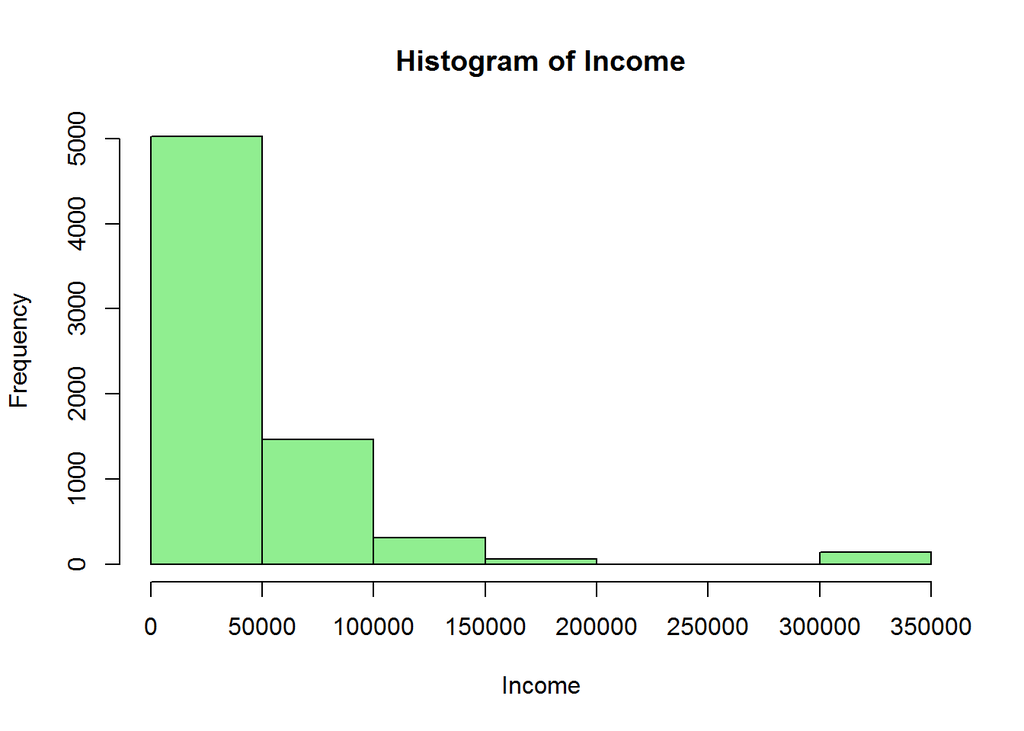

```r
Income <- heights$income
hist(Income, col = "light green", breaks = 7)
```

Проверим данные на нормальность распределения

```r
heights <- as_tibble(heights)
shapiro.test(heights$income[0:5000])
```

```
##
##  Shapiro-Wilk normality test
##
## data:  heights$income[0:5000]
## W = 0.64893, p-value < 2.2e-16
```

```r
ad.test(heights$income)$p.value # всю выборку можно проверить с помощью теста Андерсона-Дарлинга
```

```
## [1] 3.7e-24
```

Поскольку p-value меньше уровня α, который стандартно равен 0,05, то мы можем отвергнуть нулевую гипотезу о том, что выборка взята из нормального распределения.

Проведем проверку данных на ковариацию

```r
heights %>%
  drop_na() %>%
  select(income, height) %>%
  cov()
```

```
##              income      height
## income 3233484035.2 128359.0908
## height     128359.1    107.5636
```

Ковариация положительная, то есть чем больше одна переменная, тем больше другая переменная.

Проведем проверку данных на корреляцию

```r
heights %>%
  drop_na() %>%
  select(income, height) %>%
  cor()
```

```
##         income  height
## income 1.00000 0.21765
## height 0.21765 1.00000
```

Связь есть, но не очень большая (скорее ближе к 0, чем к 1).

**Диаграмма рассеяния**

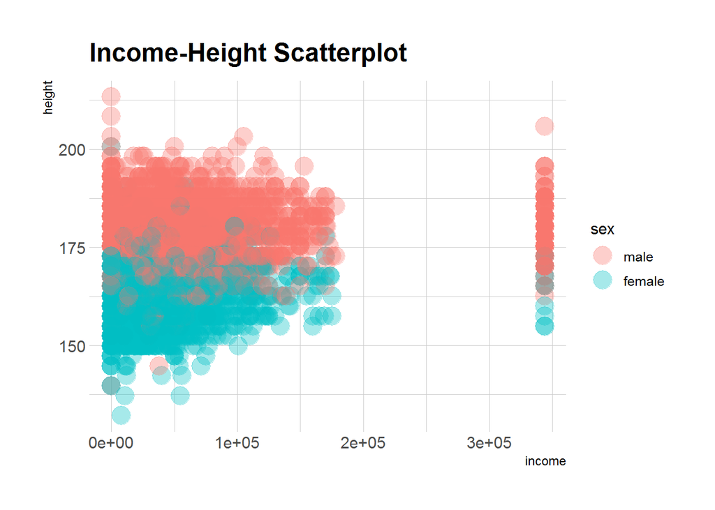

```r
ggplot(heights, aes(x=income, y=height, size=2, color=sex)) +
    geom_point(alpha=.35, size=6) +
    theme_ipsum() +
    labs(title = "Income-Height Scatterplot")
```

Насколько неслучайна эта корреляция? Протестируем уровень значимости нулевой гипотезы: корреляция этих двух величин в генеральной совокупности равна 0. Альтернативная гипотеза: между этими величинами есть какая-то связь.

```r
# для большей уверенности также проведем тест Спирмена
cor.test(heights$income, heights$height)
```

```
##
##  Pearson's product-moment correlation
##
## data:  heights$income and heights$height
## t = 18.676, df = 7004, p-value < 2.2e-16
## alternative hypothesis: true correlation is not equal to 0
## 95 percent confidence interval:
##  0.1953779 0.2399910
## sample estimates:
##       cor
## 0.2177982
```

```r
cor.test(heights$income, heights$height, method = "spearman")
```

```
##
##  Spearman's rank correlation rho
##
## data:  heights$income and heights$height
## S = 4.5234e+10, p-value < 2.2e-16
## alternative hypothesis: true rho is not equal to 0
## sample estimates:
##       rho
## 0.2107673
```

По результатам первого теста мы можем отклонить нулевую гипотезу. По результатам теста Спирмена незначительно различается только значение корреляции.

**Предположение:** наличие корреляции объясняется разницей в росте мужчин и женщин и традиционной разницей в размере их заработка.

**Средний доход по каждому полу**

```r
heights %>%
  group_by(sex) %>%
  summarise(across(c(income), mean, na.rm = TRUE))
```

```
## # A tibble: 2 x 2
##   sex    income
## * <fct>   <dbl>
## 1 male   53510.
## 2 female 29588.
```

**Средний рост по каждому полу**

```r
heights %>%
  group_by(sex) %>%
  summarise(across(c(height), mean, na.rm = TRUE))
```

```
## # A tibble: 2 x 2
##   sex    height
## * <fct>   <dbl>
## 1 male     178.
## 2 female   163.
```

**Посчитаем, сколько в наших данных мужчин и женщин**

```r
heights %>%
  count(sex, sort = TRUE)
```

```
## # A tibble: 2 x 2
##   sex        n
##   <fct>  <int>
## 1 female  3604
## 2 male    3402
```

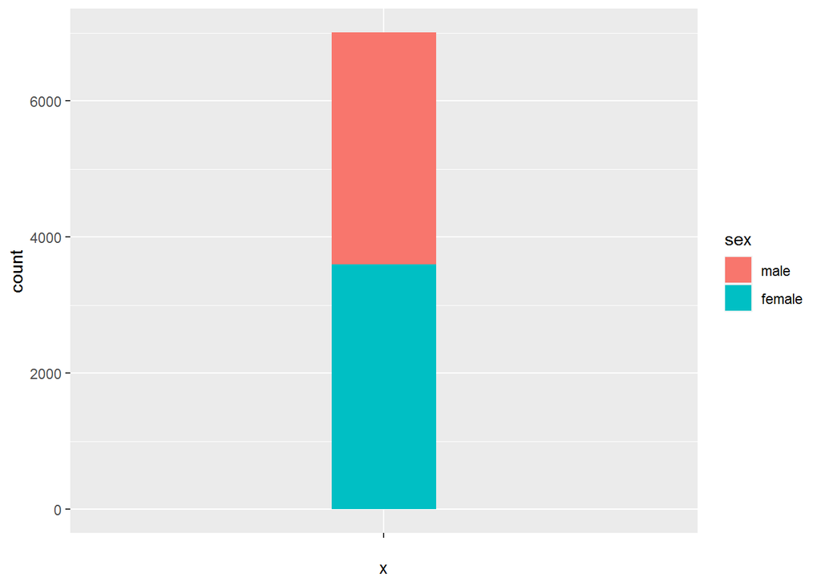

```r
ggplot(data = heights) +
  geom_bar(aes(x = "", fill = sex), width = .2)
```

**В отдельно взятых группах М и Ж значение коэффициента корреляции между** **ростом и доходом ниже, чем в смешанной группе, в 2 и 3 раза соответственно**

```r
income_height_sex <- heights %>% # проверка на кореляцию между ростом и доходом отдельно для М и Ж
  drop_na() %>%
  select(income, height, sex)

male <- income_height_sex %>%
  filter(sex == "male")
cor(male$income, male$height)
```

```
## [1] 0.1097444
```

```r
female <- income_height_sex %>%
  filter(sex == "female")
cor(female$income, female$height)
```

```
## [1] 0.07180412
```

**Результаты исследования:**

между ростом и доходом людей наблюдается корреляция, что, возможно, объясняется разницей в росте мужчин и женщин и традиционной разницей в размере их заработной платы.